# Panel Data - Assignment

Simon Munzert

11.10.2017

### Assignment 06: Panel Data

##### 1. Housing prices in an unfavorable environment

Do houses close to a garbage incinerator decrease in value? The dataset `kielmc` from the `wooldridge` package contains information about housing from North Andover, Mass. It is pooled cross-section data, with information from 1978 and 1981. An incinerator was built between these two years and we thus have a quasi-experimental situation with measurements before (1978) and after (1981) treatment. Your main hypothesis is that houses close to the incinerator lost value after the incinerator was built.

(a) Estimate separate models for the time before and after the building of the incinerator (i.e., a two-step DID) to find out whether it affect the price (in 1978 dollars) of houses near it (`nearinc`).

```r
data("kielmc")
summary(model_before <- lm(rprice ~ nearinc, data = filter(kielmc, year == 1978)))
```

```
##
## Call:
## lm(formula = rprice ~ nearinc, data = filter(kielmc, year ==
##     1978))
##
## Residuals:
##    Min     1Q Median     3Q    Max
## -56517 -16605  -3193   8683 236307
##
## Coefficients:
##             Estimate Std. Error t value Pr(>|t|)
## (Intercept)    82517       2654  31.094  < 2e-16 ***
## nearinc       -18824       4745  -3.968 0.000105 ***
## ---
## Signif. codes:  0 '***' 0.001 '**' 0.01 '*' 0.05 '.' 0.1 ' ' 1
##
## Residual standard error: 29430 on 177 degrees of freedom
## Multiple R-squared:  0.08167,    Adjusted R-squared:  0.07648
## F-statistic: 15.74 on 1 and 177 DF,  p-value: 0.0001054
```

```r
summary(model_after <- lm(rprice ~ nearinc, data = filter(kielmc, year == 1981)))
```

```
##
## Call:
## lm(formula = rprice ~ nearinc, data = filter(kielmc, year ==
##     1981))
##
## Residuals:
##    Min     1Q Median     3Q    Max
## -60678 -19832  -2997  21139 136754
##
## Coefficients:
##             Estimate Std. Error t value Pr(>|t|)
## (Intercept)   101308       3093  32.754  < 2e-16 ***
## nearinc       -30688       5828  -5.266 5.14e-07 ***
## ---
## Signif. codes:  0 '***' 0.001 '**' 0.01 '*' 0.05 '.' 0.1 ' ' 1
##
## Residual standard error: 31240 on 140 degrees of freedom
## Multiple R-squared:  0.1653, Adjusted R-squared:  0.1594
## F-statistic: 27.73 on 1 and 140 DF,  p-value: 5.139e-07
```

```r
# the implied net effect of incinerator installment
coef(model_after)[2] - coef(model_before)[2]
```

```
##  nearinc
## -11863.9
```

(b) Now use a single-equation interaction model to assess the same effect. Do you observe any difference? What, in your opinion, is the advantage of estimating a single-equation model towards estimating two separate models?

```r
summary(model_after <- lm(rprice ~ nearinc*y81, data = kielmc))
```

```
##
## Call:
## lm(formula = rprice ~ nearinc * y81, data = kielmc)
##
## Residuals:
##    Min     1Q Median     3Q    Max
## -60678 -17693  -3031  12483 236307
##
## Coefficients:
##             Estimate Std. Error t value Pr(>|t|)
## (Intercept)    82517       2727  30.260  < 2e-16 ***
## nearinc       -18824       4875  -3.861 0.000137 ***
## y81            18790       4050   4.640 5.12e-06 ***
## nearinc:y81   -11864       7457  -1.591 0.112595
## ---
## Signif. codes:  0 '***' 0.001 '**' 0.01 '*' 0.05 '.' 0.1 ' ' 1
##
## Residual standard error: 30240 on 317 degrees of freedom
## Multiple R-squared:  0.1739, Adjusted R-squared:  0.1661
## F-statistic: 22.25 on 3 and 317 DF,  p-value: 4.224e-13
```

(c) Now add controls to the model estimated in (b) for house characteristics that could also explain house prices! What happens to the effect of interest? Why?

```r
summary(model_after <- lm(rprice ~ nearinc*y81 + age + intst + land + area + rooms + baths, data = kielmc))
```

```
##
## Call:
## lm(formula = rprice ~ nearinc * y81 + age + intst + land + area +
##     rooms + baths, data = kielmc)
##
## Residuals:
##    Min     1Q Median     3Q    Max
## -74382  -9980   -591   9254 142468
##
## Coefficients:
##               Estimate Std. Error t value Pr(>|t|)
## (Intercept) -8.039e+03  1.018e+04  -0.790   0.4303
## nearinc     -1.731e+02  4.473e+03  -0.039   0.9692
## y81          1.271e+04  2.859e+03   4.446 1.22e-05 ***
## age         -2.101e+02  4.194e+01  -5.011 9.11e-07 ***
## intst       -4.003e-01  1.988e-01  -2.013   0.0449 *
## land         1.374e-01  3.190e-02   4.307 2.22e-05 ***
## area         1.814e+01  2.368e+00   7.658 2.41e-13 ***
## rooms        4.313e+03  1.689e+03   2.554   0.0111 *
## baths        1.104e+04  2.462e+03   4.486 1.02e-05 ***
## nearinc:y81 -1.077e+04  5.055e+03  -2.130   0.0339 *
## ---
## Signif. codes:  0 '***' 0.001 '**' 0.01 '*' 0.05 '.' 0.1 ' ' 1
##
## Residual standard error: 20150 on 311 degrees of freedom
## Multiple R-squared:  0.6403, Adjusted R-squared:  0.6299
## F-statistic:  61.5 on 9 and 311 DF,  p-value: < 2.2e-16
```

##### 2. Student-athletes performance

The dataset `gpa3` from the `wooldridge` package is for student-athletes from a large university for fall and spring semesters. Because you have two terms (i.e., semesters) of data for each student, an unobserved effect model is appropriate. The primary question is this: Do athletes perform more poorly in school during the semester that their sport is in season? Remember, you have data on 366 students, identiﬁed by the variable `id`, over two terms (variable `term`).

(a) Perform some descriptive operations to learn more about the basics of the data, such as how many students there are in the dataset, how the dependent variable (see below) is distributed, etc.

```r
data("gpa3")
names(gpa3)
```

```
##  [1] "term"     "sat"      "tothrs"   "cumgpa"   "season"   "frstsem"
##  [7] "crsgpa"   "verbmath" "trmgpa"   "hssize"   "hsrank"   "id"
## [13] "spring"   "female"   "black"    "white"    "ctrmgpa"  "ctothrs"
## [19] "ccrsgpa"  "ccrspop"  "cseason"  "hsperc"   "football"
```

```r
length(unique(gpa3$id))
```

```
## [1] 366
```

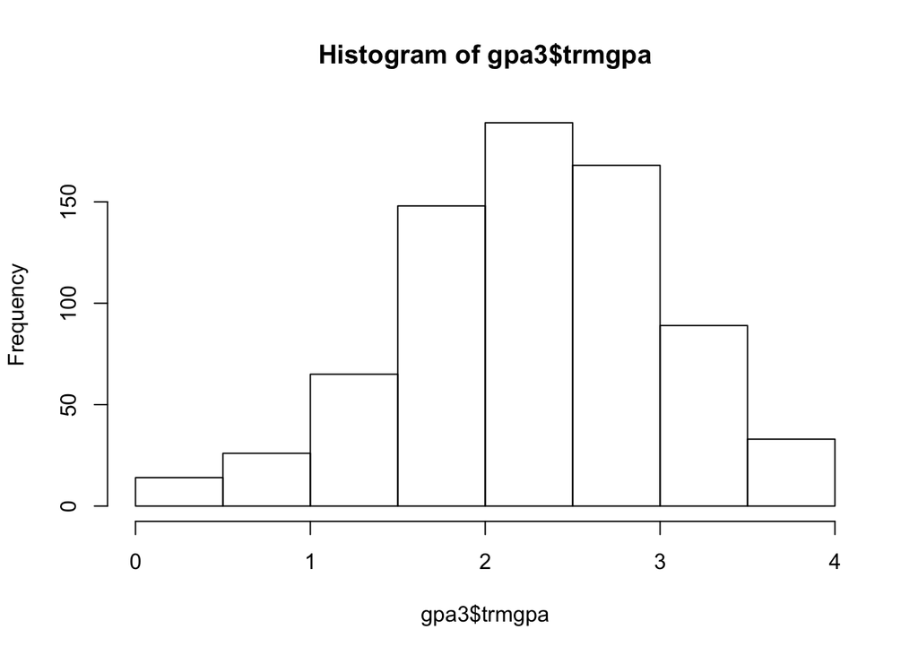

```r
hist(gpa3$trmgpa)
```

(b) Use pooled OLS to estimate a model with term GPA (`trmgpa`) as the dependent variable. The explanatory variables are `sat`, `female`, and `season`. What about the substantive size of the effects? Is season statistically signiﬁcant?

```r
summary(lm(trmgpa ~ sat + female + season, data = gpa3))
```

```
##
## Call:
## lm(formula = trmgpa ~ sat + female + season, data = gpa3)
##
## Residuals:
##      Min       1Q   Median       3Q      Max
## -2.23320 -0.37062  0.04727  0.45725  1.55160
##
## Coefficients:
##               Estimate Std. Error t value Pr(>|t|)
## (Intercept)  0.2907926  0.1277485   2.276   0.0231 *
## sat          0.0021550  0.0001371  15.714   <2e-16 ***
## female       0.5256541  0.0553212   9.502   <2e-16 ***
## season      -0.0402189  0.0506868  -0.793   0.4278
## ---
## Signif. codes:  0 '***' 0.001 '**' 0.01 '*' 0.05 '.' 0.1 ' ' 1
##
## Residual standard error: 0.622 on 728 degrees of freedom
## Multiple R-squared:  0.3299, Adjusted R-squared:  0.3271
## F-statistic: 119.4 on 3 and 728 DF,  p-value: < 2.2e-16
```

(c) Now run a model with differenced variables as well as a fixed-effects model. What do you observe?

```r
summary(plm(trmgpa ~ sat + female + season, data = gpa3, model = "fd", index = "id"))
```

```
## Oneway (individual) effect First-Difference Model
##
## Call:
## plm(formula = trmgpa ~ sat + female + season, data = gpa3, model = "fd",
##     index = "id")
##
## Balanced Panel: n=366, T=2, N=732
## Observations used in estimation: 366
##
## Residuals :
##      Min.   1st Qu.    Median   3rd Qu.      Max.
## -2.797555 -0.347197  0.016729  0.402445  2.331012
##
## Coefficients :
##               Estimate Std. Error t-value Pr(>|t|)
## (intercept) -0.0024451  0.0374965 -0.0652   0.9480
## season      -0.0514332  0.0462086 -1.1131   0.2664
##
## Total Sum of Squares:    152.49
## Residual Sum of Squares: 151.97
## R-Squared:      0.0033921
## Adj. R-Squared: 0.00065413
## F-statistic: 1.23891 on 1 and 364 DF, p-value: 0.26641
```

```r
summary(plm(trmgpa ~ sat + female + season, data = gpa3, model = "within", index = "id"))
```

```
## Oneway (individual) effect Within Model
##
## Call:
## plm(formula = trmgpa ~ sat + female + season, data = gpa3, model = "within",
##     index = "id")
##
## Balanced Panel: n=366, T=2, N=732
##
## Residuals :
##     Min.  1st Qu.   Median  3rd Qu.     Max.
## -1.40000 -0.19623  0.00000  0.19623  1.40000
##
## Coefficients :
##         Estimate Std. Error t-value Pr(>|t|)
## season -0.050124   0.041565 -1.2059   0.2286
##
## Total Sum of Squares:    76.29
## Residual Sum of Squares: 75.988
## R-Squared:      0.0039684
## Adj. R-Squared: -0.99479
## F-statistic: 1.45424 on 1 and 365 DF, p-value: 0.22863
```

##### 3. Wages… again

Use the data in `wagepan` from the `wooldridge` package for this exercise.

(a) Estimate a model that explains log(wage) by education, race and labor market experience using pooled OLS and briefly interpret the estimates and standard errors!

```r
data(wagepan)
summary(plm(lwage ~ educ + black + hisp + exper, data = wagepan, index = c("nr", "year"), model = "pooling"))
```

```
## Pooling Model
##
## Call:
## plm(formula = lwage ~ educ + black + hisp + exper, data = wagepan,
##     model = "pooling", index = c("nr", "year"))
##
## Balanced Panel: n=545, T=8, N=4360
##
## Residuals :
##      Min.   1st Qu.    Median   3rd Qu.      Max.
## -5.344996 -0.254941  0.029736  0.303506  2.502226
##
## Coefficients :
##               Estimate Std. Error t-value  Pr(>|t|)
## (Intercept)  0.0180755  0.0640265  0.2823    0.7777
## educ         0.1081419  0.0046182 23.4163 < 2.2e-16 ***
## black       -0.1393948  0.0236219 -5.9011 3.885e-09 ***
## hisp         0.0214734  0.0212210  1.0119    0.3116
## exper        0.0569994  0.0028000 20.3566 < 2.2e-16 ***
## ---
## Signif. codes:  0 '***' 0.001 '**' 0.01 '*' 0.05 '.' 0.1 ' ' 1
##
## Total Sum of Squares:    1236.5
## Residual Sum of Squares: 1050.5
## R-Squared:      0.15048
## Adj. R-Squared: 0.1497
## F-statistic: 192.863 on 4 and 4355 DF, p-value: < 2.22e-16
```

(b) Now estimate the model by fixed and random effects. How do the estimates compare?

```r
summary(model_fe <- plm(lwage ~ educ + black + hisp + exper, data = wagepan, index = c("nr", "year"), model = "within"))
```

```
## Oneway (individual) effect Within Model
##
## Call:
## plm(formula = lwage ~ educ + black + hisp + exper, data = wagepan,
##     model = "within", index = c("nr", "year"))
##
## Balanced Panel: n=545, T=8, N=4360
##
## Residuals :
##      Min.   1st Qu.    Median   3rd Qu.      Max.
## -4.148012 -0.124958  0.013641  0.161297  1.505558
##
## Coefficients :
##        Estimate Std. Error t-value  Pr(>|t|)
## exper 0.0633278  0.0023454      27 < 2.2e-16 ***
## ---
## Signif. codes:  0 '***' 0.001 '**' 0.01 '*' 0.05 '.' 0.1 ' ' 1
##
## Total Sum of Squares:    572.05
## Residual Sum of Squares: 480.25
## R-Squared:      0.16047
## Adj. R-Squared: 0.040508
## F-statistic: 729.027 on 1 and 3814 DF, p-value: < 2.22e-16
```

```r
summary(model_re <- plm(lwage ~ educ + black + hisp + exper, data = wagepan, index = c("nr", "year"), model = "random"))
```

```
## Oneway (individual) effect Random Effect Model
##    (Swamy-Arora's transformation)
##
## Call:
## plm(formula = lwage ~ educ + black + hisp + exper, data = wagepan,
##     model = "random", index = c("nr", "year"))
##
## Balanced Panel: n=545, T=8, N=4360
##
## Effects:
##                  var std.dev share
## idiosyncratic 0.1260  0.3550 0.522
## individual    0.1154  0.3397 0.478
## theta:  0.6534
##
## Residuals :
##      Min.   1st Qu.    Median   3rd Qu.      Max.
## -4.562880 -0.145343  0.027947  0.191992  1.578915
##
## Coefficients :
##               Estimate Std. Error t-value  Pr(>|t|)
## (Intercept) -0.0508066  0.1142465 -0.4447  0.656551
## educ         0.1110547  0.0091781 12.0999 < 2.2e-16 ***
## black       -0.1409738  0.0492451 -2.8627  0.004221 **
## hisp         0.0211779  0.0442619  0.4785  0.632341
## exper        0.0623468  0.0022994 27.1139 < 2.2e-16 ***
## ---
## Signif. codes:  0 '***' 0.001 '**' 0.01 '*' 0.05 '.' 0.1 ' ' 1
##
## Total Sum of Squares:    651.86
## Residual Sum of Squares: 548.86
## R-Squared:      0.158
## Adj. R-Squared: 0.15723
## F-statistic: 204.309 on 4 and 4355 DF, p-value: < 2.22e-16
```

3. Does the Hausman test suggest to use the RE model or rather to stay with the FE model? Try to adapt the model in a way that, according to the Hausman test, allows you to use an RE model!

```r
phtest(model_fe, model_re)
```

```
##
##  Hausman Test
##
## data:  lwage ~ educ + black + hisp + exper
## chisq = 4.5047, df = 1, p-value = 0.0338
## alternative hypothesis: one model is inconsistent
```